# Problem Statement

The purpose is to predict whether the Pima Indian women shows signs of diabetes or not. We are using a dataset collected by "National Institute of Diabetes and Digestive and Kidney Diseases" which consists of a number of attributes which would help us to perform this prediction.

**Constraints on data collection**

All patients whose data has been collected are females at least 21 years old of Pima Indian heritage

```python
#Import all the necessary modules
import pandas as pd
import numpy as np
import matplotlib.pyplot as plt
import seaborn as sns
from sklearn.model_selection import train_test_split
from sklearn.tree import DecisionTreeClassifier
from sklearn.metrics import accuracy_score
from sklearn.metrics import confusion_matrix
from sklearn.ensemble import RandomForestClassifier
from sklearn.ensemble import AdaBoostClassifier
from sklearn.ensemble import BaggingClassifier
from sklearn.ensemble import GradientBoostingClassifier

%matplotlib inline
```

```python
import warnings
warnings.filterwarnings('ignore')
```

# Q1. Load the PIMA Indian Diabetes file into Python DataFrame.

The file can be accessed directly from the URL (https://archive.ics.uci.edu/ml/machine-learning-databases/pima-indians-diabetes/pima-indians-diabetes.data or you may first download it to a local folder and then load it into Python dataframe. Let us assume the data frame is named pima_df

```python
df= pd.read_csv("Diabetes.csv")
```

```python
df.head()
```

|  | Pregnancies | Glucose | BloodPressure | SkinThickness | Insulin | BMI | DiabetesPedigreeFunction | Age | Outcome |
| --- | --- | --- | --- | --- | --- | --- | --- | --- | --- |
| 0 | 6 | 148 | 72 | 35 | 0 | 33.6 | 0.627 | 50 | 1 |
| 1 | 1 | 85 | 66 | 29 | 0 | 26.6 | 0.351 | 31 | 0 |
| 2 | 8 | 183 | 64 | 0 | 0 | 23.3 | 0.672 | 32 | 1 |
| 3 | 1 | 89 | 66 | 23 | 94 | 28.1 | 0.167 | 21 | 0 |
| 4 | 0 | 137 | 40 | 35 | 168 | 43.1 | 2.288 | 33 | 1 |

# Q2. Print 10 samples from the dataset

```python
df.sample(10)
```

|  | Pregnancies | Glucose | BloodPressure | SkinThickness | Insulin | BMI | DiabetesPedigreeFunction | Age | Outcome |
| --- | --- | --- | --- | --- | --- | --- | --- | --- | --- |
| 132 | 3 | 170 | 64 | 37 | 225 | 34.5 | 0.356 | 30 | 1 |
| 12 | 10 | 139 | 80 | 0 | 0 | 27.1 | 1.441 | 57 | 0 |
| 662 | 8 | 167 | 106 | 46 | 231 | 37.6 | 0.165 | 43 | 1 |
| 172 | 2 | 87 | 0 | 23 | 0 | 28.9 | 0.773 | 25 | 0 |
| 267 | 2 | 128 | 64 | 42 | 0 | 40.0 | 1.101 | 24 | 0 |
| 602 | 1 | 124 | 74 | 36 | 0 | 27.8 | 0.100 | 30 | 0 |
| 582 | 12 | 121 | 78 | 17 | 0 | 26.5 | 0.259 | 62 | 0 |
| 426 | 0 | 94 | 0 | 0 | 0 | 0.0 | 0.256 | 25 | 0 |
| 534 | 1 | 77 | 56 | 30 | 56 | 33.3 | 1.251 | 24 | 0 |
| 640 | 0 | 102 | 86 | 17 | 105 | 29.3 | 0.695 | 27 | 0 |

# Q3 Print the datatypes of each column and the shape of the dataset

```python
df.dtypes
```

```
Pregnancies                   int64
Glucose                       int64
BloodPressure                 int64
SkinThickness                 int64
Insulin                       int64
BMI                         float64
DiabetesPedigreeFunction    float64
Age                           int64
Outcome                       int64
dtype: object
```

```python
df.shape
```

```
(768, 9)
```

There are '0's in the data. Are they really valid '0's or they are missing values? Plasma, BP, skin thickness etc. these values cannot be 0. look at column by column logically to understand this.

# Q4 Replace all the 0s in the column with the median of the same column value accordingly.

```python
df.describe()
```

|  | Pregnancies | Glucose | BloodPressure | SkinThickness | Insulin | BMI | DiabetesPedigreeFunction | Age | Outcome |
| --- | --- | --- | --- | --- | --- | --- | --- | --- | --- |
| count | 768.000000 | 768.000000 | 768.000000 | 768.000000 | 768.000000 | 768.000000 | 768.000000 | 768.000000 | 768.000000 |
| mean | 3.845052 | 120.894531 | 69.105469 | 20.536458 | 79.799479 | 31.992578 | 0.471876 | 33.240885 | 0.348958 |
| std | 3.369578 | 31.972618 | 19.355807 | 15.952218 | 115.244002 | 7.884160 | 0.331329 | 11.760232 | 0.476951 |
| min | 0.000000 | 0.000000 | 0.000000 | 0.000000 | 0.000000 | 0.000000 | 0.078000 | 21.000000 | 0.000000 |
| 25% | 1.000000 | 99.000000 | 62.000000 | 0.000000 | 0.000000 | 27.300000 | 0.243750 | 24.000000 | 0.000000 |
| 50% | 3.000000 | 117.000000 | 72.000000 | 23.000000 | 30.500000 | 32.000000 | 0.372500 | 29.000000 | 0.000000 |
| 75% | 6.000000 | 140.250000 | 80.000000 | 32.000000 | 127.250000 | 36.600000 | 0.626250 | 41.000000 | 1.000000 |
| max | 17.000000 | 199.000000 | 122.000000 | 99.000000 | 846.000000 | 67.100000 | 2.420000 | 81.000000 | 1.000000 |

```python
Zero_column = ['Glucose','BloodPressure','SkinThickness','Insulin','BMI']
```

```python
for col in Zero_column:
  df[col].replace(0, df[col].median(), inplace= True)
```

# Q5 Print the descriptive statistics of each & every column using describe() function

```python
df.describe()
```

|  | Pregnancies | Glucose | BloodPressure | SkinThickness | Insulin | BMI | DiabetesPedigreeFunction | Age | Outcome |
| --- | --- | --- | --- | --- | --- | --- | --- | --- | --- |
| count | 768.000000 | 768.000000 | 768.000000 | 768.000000 | 768.000000 | 768.000000 | 768.000000 | 768.000000 | 768.000000 |
| mean | 3.845052 | 121.656250 | 72.386719 | 27.334635 | 94.652344 | 32.450911 | 0.471876 | 33.240885 | 0.348958 |
| std | 3.369578 | 30.438286 | 12.096642 | 9.229014 | 105.547598 | 6.875366 | 0.331329 | 11.760232 | 0.476951 |
| min | 0.000000 | 44.000000 | 24.000000 | 7.000000 | 14.000000 | 18.200000 | 0.078000 | 21.000000 | 0.000000 |
| 25% | 1.000000 | 99.750000 | 64.000000 | 23.000000 | 30.500000 | 27.500000 | 0.243750 | 24.000000 | 0.000000 |
| 50% | 3.000000 | 117.000000 | 72.000000 | 23.000000 | 31.250000 | 32.000000 | 0.372500 | 29.000000 | 0.000000 |
| 75% | 6.000000 | 140.250000 | 80.000000 | 32.000000 | 127.250000 | 36.600000 | 0.626250 | 41.000000 | 1.000000 |
| max | 17.000000 | 199.000000 | 122.000000 | 99.000000 | 846.000000 | 67.100000 | 2.420000 | 81.000000 | 1.000000 |

# Q6 See the distribution of 'Class' variable and plot it using appropriate graph.

```python
pd.value_counts(df['Outcome'])
```

```
0    500
1    268
Name: Outcome, dtype: int64
```

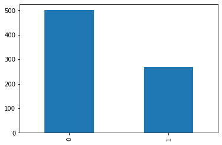

```python
pd.value_counts(df['Outcome']).plot(kind= 'bar')
```

# Just for your understanding - Using univariate analysis check the individual attributes for their basic statistic such as central values, spread, tails etc. What are your observations (any two attributes). Its an optional step and will not be graded.

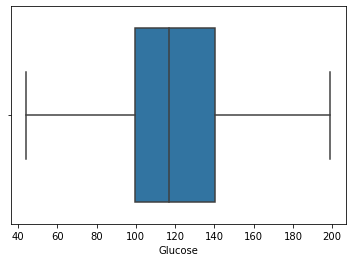

```python
sns.boxplot(x=df['Glucose'])
```

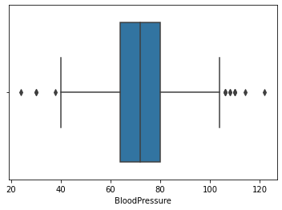

```python
sns.boxplot(x=df['BloodPressure'])
```

We can see that the Blood Pressure has some outliers

# Q7. Use pairplots and correlation method to observe the relationship between different variables and state your insights.

Hint: Use seaborn plot and check the relationship between different variables

Using the plot - infer the relationship between different variables

```python
df.corr()
```

|  | Pregnancies | Glucose | BloodPressure | SkinThickness | Insulin | BMI | DiabetesPedigreeFunction | Age | Outcome |
| --- | --- | --- | --- | --- | --- | --- | --- | --- | --- |
| Pregnancies | 1.000000 | 0.128213 | 0.208615 | 0.032568 | -0.055697 | 0.021546 | -0.033523 | 0.544341 | 0.221898 |
| Glucose | 0.128213 | 1.000000 | 0.218937 | 0.172143 | 0.357573 | 0.231400 | 0.137327 | 0.266909 | 0.492782 |
| BloodPressure | 0.208615 | 0.218937 | 1.000000 | 0.147809 | -0.028721 | 0.281132 | -0.002378 | 0.324915 | 0.165723 |
| SkinThickness | 0.032568 | 0.172143 | 0.147809 | 1.000000 | 0.238188 | 0.546951 | 0.142977 | 0.054514 | 0.189065 |
| Insulin | -0.055697 | 0.357573 | -0.028721 | 0.238188 | 1.000000 | 0.189022 | 0.178029 | -0.015413 | 0.148457 |
| BMI | 0.021546 | 0.231400 | 0.281132 | 0.546951 | 0.189022 | 1.000000 | 0.153506 | 0.025744 | 0.312249 |
| DiabetesPedigreeFunction | -0.033523 | 0.137327 | -0.002378 | 0.142977 | 0.178029 | 0.153506 | 1.000000 | 0.033561 | 0.173844 |
| Age | 0.544341 | 0.266909 | 0.324915 | 0.054514 | -0.015413 | 0.025744 | 0.033561 | 1.000000 | 0.238356 |
| Outcome | 0.221898 | 0.492782 | 0.165723 | 0.189065 | 0.148457 | 0.312249 | 0.173844 | 0.238356 | 1.000000 |

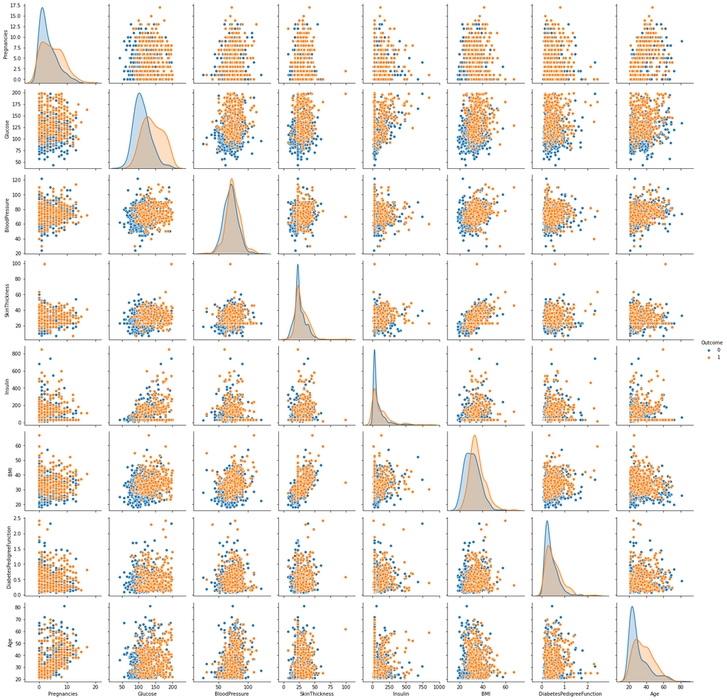

```python
sns.pairplot(df,hue= 'Outcome')
```

We can see that the attributes are week

# Q8 Split the pima_df into training and test set in the ratio of 70:30 (Training:Test).</b>

```python
x = df.iloc[:, 0:8]
y= df['Outcome']
```

```python
x_train, x_test, y_train, y_test = train_test_split(x, y, test_size = 0.30, random_state=9, stratify=y)
```

```python
print(x_train.shape)
print(x_test.shape)
print(y_train.shape)
print(y_test.shape)
```

```
(537, 8)
(231, 8)
(537,)
(231,)
```

# Q9 Create the decision tree model using “entropy” method of reducing the entropy and fit it to training data.</b>

```python
dt= DecisionTreeClassifier (criterion= 'entropy')
dt.fit (x_train, y_train)

y_pred_train = dt.predict(x_train)
accuracy_score(y_train, y_pred_train)
```

```
1.0
```

# Q10 Print the accuracy of the model & print the confusion matrix

```python
y_pred_test = dt.predict(x_test)
accuracy_score(y_test, y_pred_test)
```

```
0.7575757575757576
```

```python
confusion_matrix(y_test, y_pred_test)
```

```
array([[118,  32],
       [ 24,  57]], dtype=int64)
```

# Q11 Print the feature importance of the decision model

```python
dt.feature_importances_
```

```
array([0.04943018, 0.30946768, 0.08283993, 0.03209599, 0.04419593,
       0.19905411, 0.15307524, 0.12984094])
```

```python
pd.DataFrame({'Columns':df.columns[:-1],'Imp_Features':dt.feature_importances_}).sort_values(by='Imp_Features',ascending=False)
```

|  | Columns | Imp_Features |
| --- | --- | --- |
| 1 | Glucose | 0.309468 |
| 5 | BMI | 0.199054 |
| 6 | DiabetesPedigreeFunction | 0.153075 |
| 7 | Age | 0.129841 |
| 2 | BloodPressure | 0.082840 |
| 0 | Pregnancies | 0.049430 |
| 4 | Insulin | 0.044196 |
| 3 | SkinThickness | 0.032096 |

# Q12 Apply the Random forest model and print the accuracy of Random forest Model

```python
rf = RandomForestClassifier()
rf.fit(x_train, y_train)

accuracy_score(y_train, rf.predict(x_train))
```

```
1.0
```

```python
accuracy_score(y_test, rf.predict(x_test))
```

```
0.7619047619047619
```

```python
confusion_matrix(y_test, rf.predict(x_test))
```

```
array([[132,  18],
       [ 37,  44]], dtype=int64)
```

# Q13 Apply Adaboost Ensemble Algorithm for the same data and print the accuracy.

```python
ad= AdaBoostClassifier(base_estimator=dt)
ad.fit(x_train, y_train)
accuracy_score(y_train, ad.predict(x_train))
```

```
1.0
```

```python
accuracy_score(y_test, ad.predict(x_test))
```

```
0.7878787878787878
```

```python
confusion_matrix(y_test, ad.predict(x_test))
```

```
array([[123,  27],
       [ 22,  59]], dtype=int64)
```

# Q14 - Apply Bagging Classifier Algorithm and print the accuracy.

```python
bgc= BaggingClassifier()
bgc.fit(x_train, y_train)
accuracy_score(y_train, bgc.predict(x_train))
```

```
0.9851024208566108
```

```python
accuracy_score(y_test, bgc.predict(x_test))
```

```
0.8181818181818182
```

```python
confusion_matrix(y_test, bgc.predict(x_test))
```

```
array([[138,  12],
       [ 30,  51]], dtype=int64)
```

# Q15 - Apply GradientBoost Classifier Algorithm for the same data and print the accuracy

```python
gbc= GradientBoostingClassifier()
gbc.fit(x_train, y_train)
accuracy_score(y_train, gbc.predict(x_train))
```

```
0.9236499068901304
```

```python
accuracy_score(y_test, gbc.predict(x_test))
```

```
0.7705627705627706
```

```python
confusion_matrix(y_test, gbc.predict(x_test))
```

```
array([[131,  19],
       [ 34,  47]], dtype=int64)
```

# Next steps are optional and will not be graded.

Voting is one of the simplest ways of combining the predictions from multiple machine learning algorithms.

It works by first creating two or more standalone models from your training dataset. A Voting Classifier can then be used to wrap your models and average the predictions of the sub-models when asked to make predictions for new data.

Apply Voting Classfier on the given dataset and state your insights.

Hard Voting

```python
from sklearn.ensemble import VotingClassifier

vt = VotingClassifier(estimators = [('rf', RandomForestClassifier()), ('bgc', BaggingClassifier()), ('gbc', GradientBoostingClassifier())], voting ='hard')
vt.fit(x_train, y_train)
accuracy_score(y_train, vt.predict(x_train))
```

```
0.9906890130353817
```

```python
accuracy_score(y_test, vt.predict(x_test))
```

```
0.7878787878787878
```

```python
confusion_matrix(y_test, vt.predict(x_test))
```

```
array([[131,  19],
       [ 30,  51]], dtype=int64)
```

Soft Voting

```python
from sklearn.ensemble import VotingClassifier

vt = VotingClassifier(estimators = [('rf', RandomForestClassifier()), ('bgc', BaggingClassifier()), ('gbc', GradientBoostingClassifier())], voting ='soft')
vt.fit(x_train, y_train)
accuracy_score(y_train, vt.predict(x_train))
```

```
0.994413407821229
```

```python
accuracy_score(y_test, vt.predict(x_test))
```

```
0.7662337662337663
```

```python
confusion_matrix(y_test, vt.predict(x_test))
```

```
array([[126,  24],
       [ 30,  51]], dtype=int64)
```

```python
from sklearn.ensemble import StackingClassifier
sc = StackingClassifier(estimators =[('rf', RandomForestClassifier()),('bgc', BaggingClassifier()), ('gbc', GradientBoostingClassifier())])
sc.fit(x_train, y_train)
accuracy_score(y_train, sc.predict(x_train))
```

```
0.9832402234636871
```

```python
accuracy_score(y_test, sc.predict(x_test))
```

```
0.7662337662337663
```

```python
confusion_matrix(y_test, sc.predict(x_test))
```

```
array([[130,  20],
       [ 34,  47]], dtype=int64)
```